# 2018201743-张嘉辰-第四周作业

Zhang Jiachen

2020年10月14日

# 1. 最小次序统计量的分布函数

最小次序统计量 $X_{(1)}$ 的分布函数为

$F_{1}(x)$

$=P\left(X_{(1)} \leq x\right)=P\left(\right.$ 至少1个 $X_{i}$ 小于或等于 $\left.x\right)$

$=\sum_{i=1}^{n}\left(\begin{array}{l}n \\ i\end{array}\right) F(x)^{i}[1-F(x)]^{n-i}$

如果总体分布密度 $f(x)$ 存在，则最小次序统计量 $X_{(1)}$ 的分布函数为

$f_{1}(x)=\frac{n !}{(n-1) !} f(x)[1-F(x)]^{n-1}$

以下计算按照上述公式进行。

```r
#引入geyser数据集
library(MASS)
attach(geyser)

#样本量
n <- 20

#在已知总体（geyser$duration）的前提下，geyser$duration的分布是离散的均匀分布，分布函数可以用经验分布函数来计算
Fx <- ecdf(geyser$duration)

#根据最小次序统计量的分布函数的表达式，将其分为三部分，分别计算
#计算表达式中的常数项
constant <- function(j){
  return(choose(n,j))
}
#计算表达式中分布函数的j次方
Fx1 <- function(x,j){
  return(Fx(x)^j)
}
#计算表达式中（1-分布函数）的（n-j）次方
Fx2 <- function(x, j){
  return((1-Fx(x))^(n-j))
}
#根据最小次序统计量的分布函数的表达式，将上面三部分的乘积求和，得到其分布函数F_min
F_min  <-  function(x) {
  res <- 0
  for(i in 1:n){
    res <- res + constant(i)*Fx1(x,i)*Fx2(x,i)
  }
  return(res)
}

#最小次序统计量可能取到的最小值
min_duration <- min(duration)
min_duration
```

```
## [1] 0.8333333
```

```r
#最小次序统计量可能取到的最大值
max_duration <- sort(duration, decreasing = TRUE)[20]
max_duration
```

```
## [1] 4.766667
```

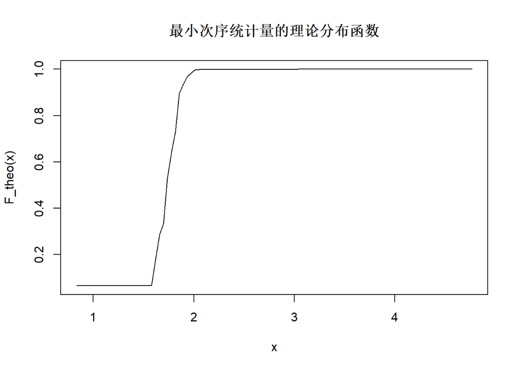

```r
#最小次序统计量的理论分布函数在定义域[0.83,4.77]上的图像
plot(function(x) F_min(x), from = min_duration, to = max_duration, main = "最小次序统计量的理论分布函数", xlab = "x", ylab = "F_theo(x)")
```

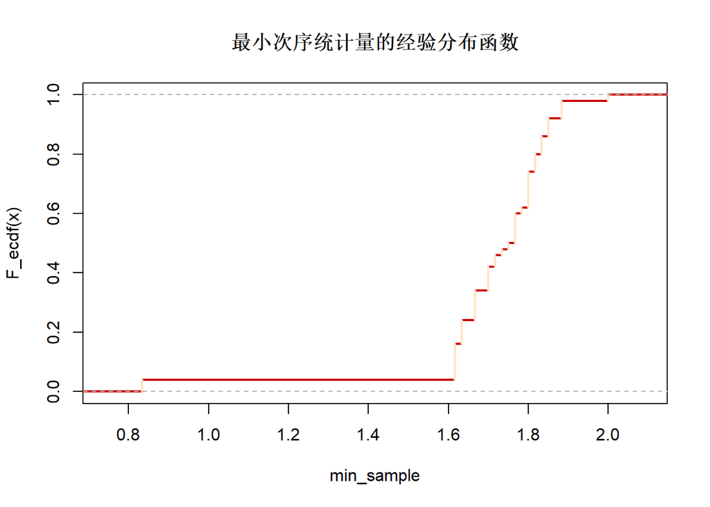

```r
#下面通过抽样求出最小次序统计量的经验分布函数
#50个样本的最小值记录在min_s中
#初始化
min_s <- rep(0,50)
#得到最小值的观测样本
for(i in 1:50){
#不放回地抽取20个数据
  samp <- sample(duration, 20, replace = FALSE)
  min_samp <- min(samp)
  min_s[i] <- min_samp
}

#用plot()和ggplot2包画出最小次序统计量的经验分布函数

#画图方式1：用plot函数
#用ecdf()函数计算min_s的经验分布函数
Fn_min_samp <- ecdf(min_s)
#画出min_s的经验分布函数
#用plot函数
#设置与x轴平行的线为红色，与y轴平行的线为黄色，阶梯转折点为蓝色
plot(Fn_min_samp, verticals = TRUE,do.points =TRUE,lwd=2,col.points="steelblue",cex=0.1,col.hor="red3",col.vert="bisque",main="最小次序统计量的经验分布函数", xlab = "min_sample", ylab = "F_ecdf(x)")

#画图方式1：用ggplot函数
min_df <- as.data.frame(min_s)
library(ggplot2)
```

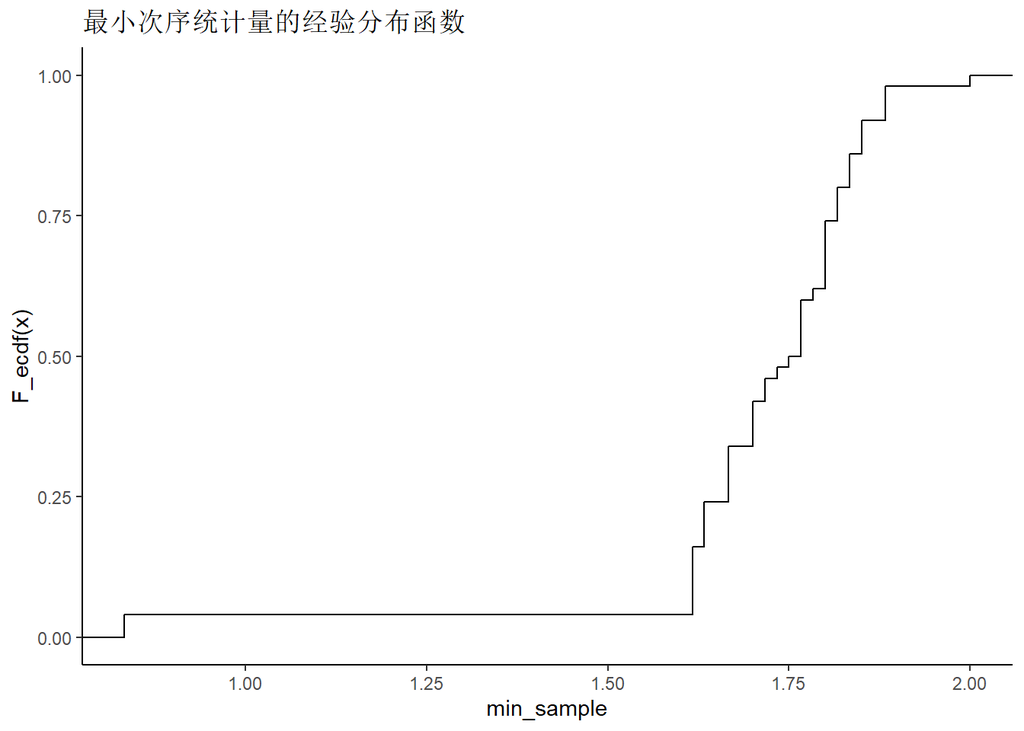

```r
ggplot(min_df, aes(min_s)) + stat_ecdf(geom = "step") +
   theme(panel.border = element_blank(), panel.grid.major = element_blank(), panel.grid.minor = element_blank(), axis.line = element_line(colour = "black"), axis.ticks = element_blank()) + theme_classic() +
  labs(title="最小次序统计量的经验分布函数",
     y = "F_ecdf(x)", x="min_sample")
```

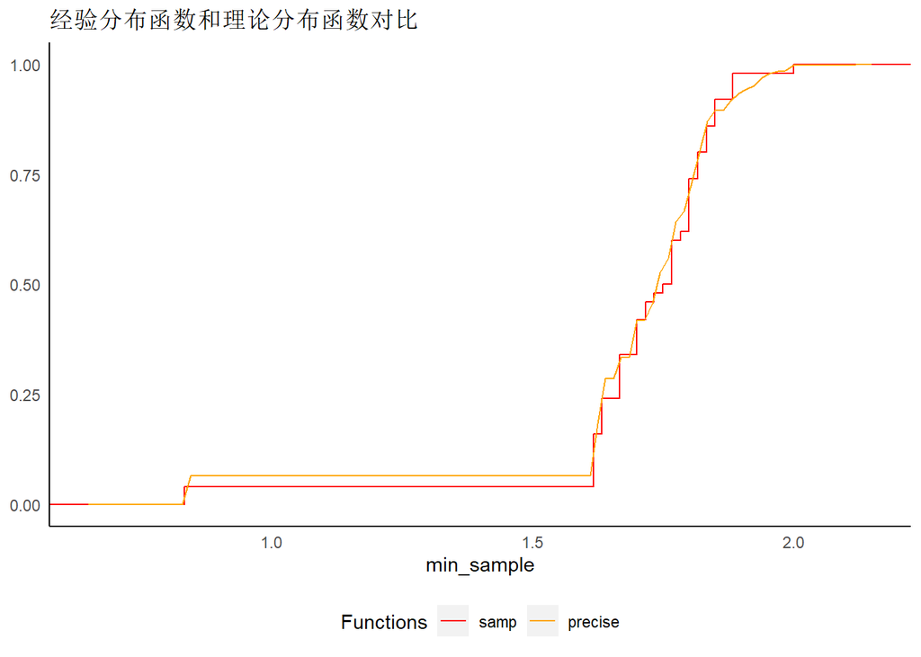

```r
#将经验分布函数和理论分布函数画在同一张图上，进行比较
plot.range1 <- data.frame(x=min_s, Functions = factor(1))
#由于抽样时，抽到样本的最小值超过2.2的概率很小，所以为了便于比较，将理论分布函数中x的范围调整到和经验分布函数比较接近
plot.range2 <- data.frame(x=c(0.65, 2.15), Functions = factor(2))

ggplot(NULL, aes(x=x, colour=Functions)) +
#画出经验分布函数，颜色为红色
  stat_ecdf(data = plot.range1, geom = "step") +
#画出理论分布函数，颜色为橙色
  stat_function(data = plot.range2, fun = F_min) +
  scale_colour_manual(values = c("red", "orange"), labels = c("samp", "precise")) +
  theme(axis.title.y=element_blank(), panel.border = element_blank(), panel.grid.major = element_blank(), panel.grid.minor = element_blank(), axis.line = element_line(colour = "black"), axis.ticks = element_blank(), panel.background = element_blank(), legend.position = "bottom") +
  labs(title="经验分布函数和理论分布函数对比",
     y = "F(x)", x="min_sample")
```

上图中，红色线为经验分布函数，橙色线为理论分布函数。

从图上观察得到，经验分布函数和理论分布函数较为接近。

# 2.U统计量

## 2.1

证明：

$E(\operatorname{sgn}(x))=P(x>0)-P(x<0)$

$E\left(h\left(X_{1}, X_{2}, X_{3}\right)\right)=E\left(\operatorname{sgn}\left(2 X_{1}-X_{2}-X_{3}\right)\right)$

$=P\left(2 X_{1}-X_{2}-X_{3}>0\right)-P\left(2 X_{1}-X_{2}-X_{3}<0\right)$

$=P\left(X_{1}>\frac{X_{2}+X_{3}}{2}\right)-P\left(X_{1}<\frac{X_{2}+X_{3}}{2}\right)=\theta(F)$

所以

$h\left(X_{1}, X_{2}, X_{3}\right)=\operatorname{sgn}\left(2 X_{1}-X_{2}-X_{3}\right)$ 是

概率 $\theta(F)=P\left(X_{1}>\frac{X_{2}+X_{3}}{2}\right)-P\left(X_{1}<\frac{X_{2}+X_{3}}{2}\right) \cdot$ 的无偏估计。

## 2.2

证明：

$F(x)$ 对称，则有 $P\left(2 X_{1}-\left(X_{2}+X_{3}\right)>0\right)=P\left(2 X_{1}-\left(X_{2}+X_{3}\right)<0\right)=\frac{1}{2}$

因此 $\theta(F)=P\left(X_{1}>\frac{X_{2}+X_{3}}{2}\right)-P\left(X_{1}<\frac{X_{2}+X_{3}}{2}\right)=0$

## 2.3

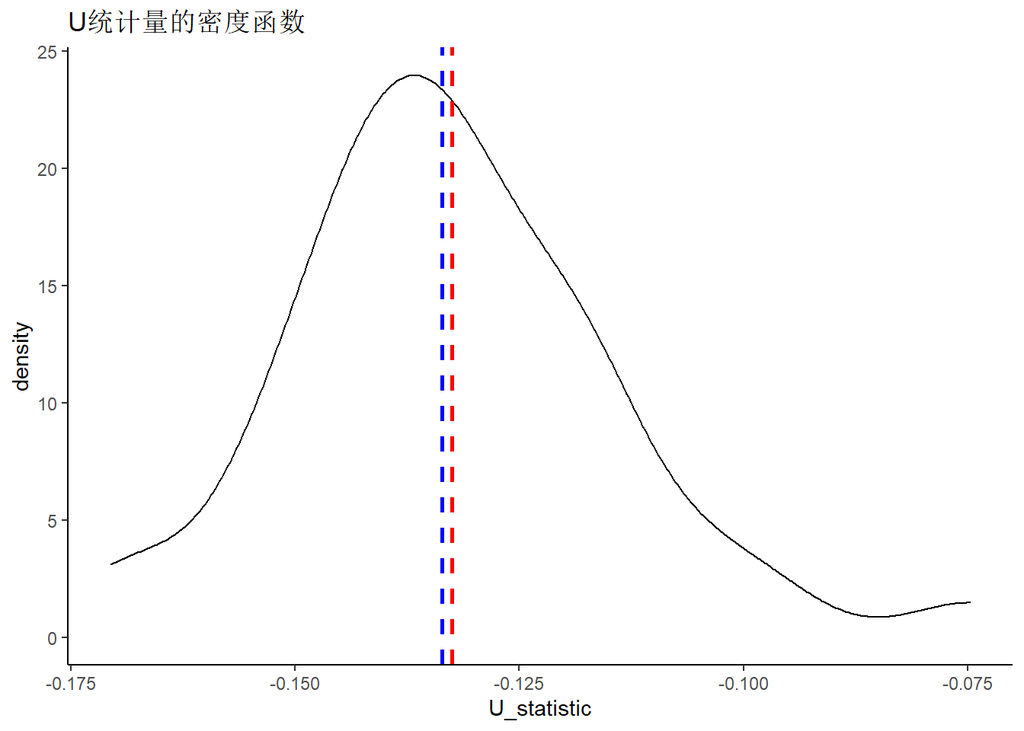

```r
#参数X为向量
#定义h(X1,X2,X3)
h <- function(X){
  if(((2*X[1]) -X[2] - X[3])>0){
    return(1)
  }else if((2*X[1] -X[2] - X[3])<0){
    return(-1)
  }else{return(0)}
}
#对X1,X2,X3所有可能排列得到的h(X)求平均，得到对称的估计
h_sym <- function(X){
  library(gtools)
#permu的每一行是X1,X2,X3的一种可能排列
  permu <- permutations(3, 3, X)
#对每一种X1,X2,X3的可能排列求出h(X)后再平均
  h_permu <- apply(permu, 1, h)
  return(sum(h_permu)/6)
}
#得到U统计量
U_stat <- function(samp, num, k){
  library(gtools)
#combi的每一行都是从samp中任意选取三个值作为X1,X2,X3的一个可能结果
  combi <- combinations(num, k, samp)
  h_sym_samp <- apply(combi, 1, h_sym)
  return(sum(h_sym_samp)/(choose(num, k)))
}

#样本量
N <- 40
#一共抽Num_samp组样本，每组样本的样本量都是N
Num_samp <- 40
#初始化U统计量
res_U_allsamp <- rep(0, Num_samp)
#对每一组样本求得U统计量
for(i in 1:Num_samp){
#从N(0,1)中选取随机数alpha
  alpha_samp <- rnorm(N)
  x <- exp(alpha_samp)
#对这一组样本计算U统计量，存入res_U_allsamp中
  res <- U_stat(x, N, 3)
  res_U_allsamp[i] <- res
}
#构建数据框用于作图
df <- as.data.frame(res_U_allsamp)
library(ggplot2)
ggplot(df, aes(x = res_U_allsamp)) + geom_density() +
#增加红色虚线，标识均值所在的位置
  geom_vline(aes(xintercept=mean(res_U_allsamp)),
               color="red", linetype="dashed", size=1) +
#增加蓝色虚线，标识中位数所在的位置
  geom_vline(aes(xintercept=median(res_U_allsamp)),
               color="blue", linetype="dashed", size=1) +
#设置坐标轴和背景格式
  theme(panel.border = element_blank(), panel.grid.major = element_blank(), panel.grid.minor = element_blank(), axis.line = element_line(colour = "black"), axis.ticks = element_blank()) + theme_classic() +
  labs(title="U统计量的密度函数",
     y = "density", x="U_statistic")
```

图上的红色线为均值所在的位置，蓝色线为中位数所在的位置。可以看出均值大于中位数。

从图上可以看出，U统计量的分布是右偏的。

$\theta(F)≠0$，$F(x)$不是对称的。

X的分布也是右偏的。